# Enron’s Story Through Emails: A Dashboard Analysis

2024-11-22

> KEY FINDINGS

This analysis presents data on the Enron company’s situation from 1999 to 2002, based on email communications among 149 staff members.

Below is a summary of the key findings from the exploration of the Enron email database:

1. A total of `252,349` email conversations occurred over the four-year period.
2. `149` staff members were active in the company during this time.
3. `The year 2001` recorded the highest email volume, with `October 25, 2001`, marking the single day with the most email activity. On this day, the email volume was nearly half the total number of emails sent throughout 1999.

From the data and historical context, we can infer trends in communication patterns. Between 1999 and 2000, Enron appeared to be in a phase of growth and development. However, starting in mid-2001, financial discrepancies were identified in the company’s reports. By November 2001, Enron’s stock price had plunged from a high of $90 per share in mid-2000 to less than $12 per share. The surge in email activity in October 2001 aligns with the unfolding crisis, as employees likely sought to address the mounting challenges. (Sources: Enron Scandal, Britannica, Enron Scandal, Wikipedia)

4. `The three most frequent words` in email subjects on October 25, 2001, were `"10," "2001," and "meeting".` This suggests that the company may have been organizing additional meetings on this date to address critical issues.

> STEPS TO APPROACHING DATASETS
1. Understand the Database Structure • Examine the relationships among tables to gain an overview of the database structure and identify key connections.
2. Data Cleaning • Process and clean the data to ensure accuracy, consistency, and usability for analysis.
3. Begin Data Analysis Based on Four Key Questions
1. Identify the Most Active Enron Employees: • Determine the Top 10 senders based on the number of emails sent within the database.
2. Analyze User Roles and Status: • Examine the positions or roles of the Top 10 senders identified by the number of emails.
3. Explore Temporal Dynamics of Messages: • Analyze the email volume by year using a histogram to visualize trends over time.
4. Perform a Basic Content Analysis of Messages: • Identify the three most frequent words in the email subjects on the date with the highest email volume.

> Load Enron.rdata into the R Markdown document

```r
load("Enron.RData")
```

- Install & load libraries to analysis data

```r
# run app
library(shiny)

# package to deal with large databases
library(dplyr)
# extract words
library(tidyr)

library(tidytext)

# Install package to create relational database: dm = data model

# install.packages("dm")
library(dm)
```

```r
# plot
library(ggplot2)

# dashboard: install.packages("shinydashboard")
library(shinydashboard)
# export to excel
library(writexl)
```

> STEP 0: OVERVIEW THE RELATIONSHIP AMONG TABLES

```r
# Create the data model with all tables
dm <- dm() %>%
  dm_add_tbl(employeelist, message, recipientinfo, referenceinfo)
```

```r
# Create a data model with all four tables
dm_model <- dm() %>%
  dm_add_tbl(employeelist, message, recipientinfo, referenceinfo) %>%

  # Define primary keys
  dm_add_pk(employeelist, Email_id) %>%
  dm_add_pk(message, mid) %>%
  dm_add_pk(recipientinfo, mid) %>%
  dm_add_pk(referenceinfo, mid) %>%

  # Define foreign keys based on relationships
  dm_add_fk(message, sender, employeelist) %>%
  dm_add_fk(recipientinfo, mid, message) %>%
  dm_add_fk(referenceinfo, mid, recipientinfo) %>%

  # Additional foreign key: recipientinfo to employeelist on rvalue = Email_id
  dm_add_fk(recipientinfo, rvalue, employeelist, Email_id)

# Visualize the data model
dm_model %>% dm_draw()
```

[interactive chart not shown]

> STEP 1: CLEAN DATASET
> 1. Table: ‘employeelist’

```r
head(employeelist,5)
```

```
##   eid firstName lastName                Email_id                     Email2
## 1  13     Marie    Heard   marie.heard@enron.com
## 2   6      Mark   Taylor mark.e.taylor@enron.com      mark.taylor@enron.com
## 3  19     Lindy   Donoho  lindy.donoho@enron.com          ldonoho@enron.com
## 4 115      Lisa     Gang     lisa.gang@enron.com
## 5 129   Jeffrey Skilling jeff.skilling@enron.com jeffrey.skilling@enron.com
##               Email3 EMail4     folder   status
## 1                              heard-m     <NA>
## 2 e.taylor@enron.com          taylor-m Employee
## 3                             donoho-l Employee
## 4                               gang-l      N/A
## 5                           skilling-j      CEO
```

- convert all column names to lowercase

```r
employeelist <- employeelist %>%
 rename_with(tolower)


head(employeelist, 5)
```

```
##   eid firstname lastname                email_id                     email2
## 1  13     Marie    Heard   marie.heard@enron.com
## 2   6      Mark   Taylor mark.e.taylor@enron.com      mark.taylor@enron.com
## 3  19     Lindy   Donoho  lindy.donoho@enron.com          ldonoho@enron.com
## 4 115      Lisa     Gang     lisa.gang@enron.com
## 5 129   Jeffrey Skilling jeff.skilling@enron.com jeffrey.skilling@enron.com
##               email3 email4     folder   status
## 1                              heard-m     <NA>
## 2 e.taylor@enron.com          taylor-m Employee
## 3                             donoho-l Employee
## 4                               gang-l      N/A
## 5                           skilling-j      CEO
```

- rename: email_id = email_1

```r
employeelist_rename <- employeelist %>%
 rename(email1 = email_id)

head(employeelist, 5)
```

```
##   eid firstname lastname                email_id                     email2
## 1  13     Marie    Heard   marie.heard@enron.com
## 2   6      Mark   Taylor mark.e.taylor@enron.com      mark.taylor@enron.com
## 3  19     Lindy   Donoho  lindy.donoho@enron.com          ldonoho@enron.com
## 4 115      Lisa     Gang     lisa.gang@enron.com
## 5 129   Jeffrey Skilling jeff.skilling@enron.com jeffrey.skilling@enron.com
##               email3 email4     folder   status
## 1                              heard-m     <NA>
## 2 e.taylor@enron.com          taylor-m Employee
## 3                             donoho-l Employee
## 4                               gang-l      N/A
## 5                           skilling-j      CEO
```

=> Pivot the four email columns to identify duplicate emails. Then, assess whether the supplementary emails in columns 2 to 4 are useful. Based on this evaluation, decide whether to keep or drop them

```r
# Pivot the email columns into a long format
employeelist_long <- employeelist_rename  %>%
  pivot_longer(cols = starts_with("email"),
               names_to = "num_email",
               values_to = "email_id") %>%
  filter(!is.na(email_id))

# Check for duplicates and filter for rows where email_id is NA or blank
duplicates <- employeelist_long %>%
  filter(is.na(email_id) | email_id == "" | duplicated(email_id)) %>%
  group_by(email_id) %>%
  filter(n() > 1 | is.na(email_id) | email_id == "") %>%
  ungroup()

# View duplicates and rows with NA or blank email_id
print(duplicates)
```

```
## # A tibble: 299 × 7
##      eid firstname lastname folder     status   num_email email_id
##    <dbl> <chr>     <chr>    <chr>      <fct>    <chr>     <chr>
##  1    13 Marie     Heard    heard-m    <NA>     email2    ""
##  2    13 Marie     Heard    heard-m    <NA>     email3    ""
##  3    13 Marie     Heard    heard-m    <NA>     email4    ""
##  4     6 Mark      Taylor   taylor-m   Employee email4    ""
##  5    19 Lindy     Donoho   donoho-l   Employee email3    ""
##  6    19 Lindy     Donoho   donoho-l   Employee email4    ""
##  7   115 Lisa      Gang     gang-l     N/A      email2    ""
##  8   115 Lisa      Gang     gang-l     N/A      email3    ""
##  9   115 Lisa      Gang     gang-l     N/A      email4    ""
## 10   129 Jeffrey   Skilling skilling-j CEO      email3    ""
## # ℹ 289 more rows
```

```r
# Remove rows where email_id is NA or bank
employeelist_long <- employeelist_long %>%
  filter(!is.na(email_id) & email_id != "")

# View the result to check for NA removal
head(employeelist_long, 5)
```

```
## # A tibble: 5 × 7
##     eid firstname lastname folder   status   num_email email_id
##   <dbl> <chr>     <chr>    <chr>    <fct>    <chr>     <chr>
## 1    13 Marie     Heard    heard-m  <NA>     email1    marie.heard@enron.com
## 2     6 Mark      Taylor   taylor-m Employee email1    mark.e.taylor@enron.com
## 3     6 Mark      Taylor   taylor-m Employee email2    mark.taylor@enron.com
## 4     6 Mark      Taylor   taylor-m Employee email3    e.taylor@enron.com
## 5    19 Lindy     Donoho   donoho-l Employee email1    lindy.donoho@enron.com
```

- Create the new columns as fullname = first name + last name

```r
# Create a new column fullname by combining firstname and lastname with a space
employeelist_long <- employeelist_long %>%
  mutate(fullname = paste(firstname, lastname, sep = " "))

# View the result
head(employeelist_long, 5)
```

```
## # A tibble: 5 × 8
##     eid firstname lastname folder   status   num_email email_id         fullname
##   <dbl> <chr>     <chr>    <chr>    <fct>    <chr>     <chr>            <chr>
## 1    13 Marie     Heard    heard-m  <NA>     email1    marie.heard@enr… Marie H…
## 2     6 Mark      Taylor   taylor-m Employee email1    mark.e.taylor@e… Mark Ta…
## 3     6 Mark      Taylor   taylor-m Employee email2    mark.taylor@enr… Mark Ta…
## 4     6 Mark      Taylor   taylor-m Employee email3    e.taylor@enron.… Mark Ta…
## 5    19 Lindy     Donoho   donoho-l Employee email1    lindy.donoho@en… Lindy D…
```

- Connect to the message table to give the final decision to keep or remove this indicators

```r
employ_text <- left_join(message, employeelist_long, by = c("sender" = "email_id"))

head(employ_text, 5)
```

```
##   mid                    sender       date
## 1  52   press.release@enron.com 2000-01-21
## 2  53 office.chairman@enron.com 2000-01-24
## 3  54 office.chairman@enron.com 2000-01-24
## 4  55   press.release@enron.com 2000-02-02
## 5  56 office.chairman@enron.com 2000-02-07
##                                      message_id
## 1 <12435833.1075863606729.JavaMail.evans@thyme>
## 2 <29664079.1075863606676.JavaMail.evans@thyme>
## 3 <15300605.1075863606629.JavaMail.evans@thyme>
## 4 <10522232.1075863606538.JavaMail.evans@thyme>
## 5 <16056123.1075863606515.JavaMail.evans@thyme>
##                                                                               subject
## 1 ENRON HOSTS ANNUAL ANALYST CONFERENCE PROVIDES BUSINESS OVERVIEW AND GOALS FOR 2000
## 2                                                     Over $50 -- You made it happen!
## 3                                                     Over $50 -- You made it happen!
## 4                 ROAD-SHOW.COM Q4i.COM CHOOSE ENRON TO DELIVER FINANCIAL WEB CONTENT
## 5                                                        Fortune Most Admired Ranking
##   eid firstname lastname folder status num_email fullname
## 1  NA      <NA>     <NA>   <NA>   <NA>      <NA>     <NA>
## 2  NA      <NA>     <NA>   <NA>   <NA>      <NA>     <NA>
## 3  NA      <NA>     <NA>   <NA>   <NA>      <NA>     <NA>
## 4  NA      <NA>     <NA>   <NA>   <NA>      <NA>     <NA>
## 5  NA      <NA>     <NA>   <NA>   <NA>      <NA>     <NA>
```

- Count how many email from 2 to 4 using in the message table

```r
r_check_emails_counts <- table(employ_text$num_email)
print(r_check_emails_counts)
```

```
##
## email1 email3
## 104766   1170
```

=>Based on the results, email_1 appears to be the primary email associated with the company, which aligns with expectations.

Among emails 2 to 4, only email_3 was referenced in the message system between 1999 and 2002. Therefore, only email_1 and email_3 are retained in the message system.

```r
employeelist_long_update <- employeelist_long %>%
 filter(num_email %in% c("email1", "email3"))

head(employeelist_long_update, 5)
```

```
## # A tibble: 5 × 8
##     eid firstname lastname folder   status   num_email email_id         fullname
##   <dbl> <chr>     <chr>    <chr>    <fct>    <chr>     <chr>            <chr>
## 1    13 Marie     Heard    heard-m  <NA>     email1    marie.heard@enr… Marie H…
## 2     6 Mark      Taylor   taylor-m Employee email1    mark.e.taylor@e… Mark Ta…
## 3     6 Mark      Taylor   taylor-m Employee email3    e.taylor@enron.… Mark Ta…
## 4    19 Lindy     Donoho   donoho-l Employee email1    lindy.donoho@en… Lindy D…
## 5   115 Lisa      Gang     gang-l   N/A      email1    lisa.gang@enron… Lisa Ga…
```

- Check the position

```r
# check the position unique

unique(employeelist_long_update$status)
```

```
##  [1] <NA>              Employee          N/A               CEO
##  [5] Director          Trader            President         Vice President
##  [9] Manager           Managing Director In House Lawyer
## 10 Levels: CEO Director Employee In House Lawyer Manager ... Vice President
```

```r
# Convert the 'status' column to a character type to ensure that R does not treat it as a factor, which would otherwise result in automatic conversion to numeric values.

employeelist_long_update$status <- as.character(employeelist_long_update$status)

# Replace NA values with "N/A"
employeelist_long_update$status <- ifelse(is.na(employeelist_long_update$status), "N/A", employeelist_long_update$status)

# Verify the change
unique(employeelist_long_update$status)
```

```
##  [1] "N/A"               "Employee"          "CEO"
##  [4] "Director"          "Trader"            "President"
##  [7] "Vice President"    "Manager"           "Managing Director"
## [10] "In House Lawyer"
```

- Count the number of staffs with their position + see the number of email

```r
# Calculate the count of staff members by status and the number of emails per staff
staff_email_count <- employeelist_long_update %>%
  group_by(status, eid) %>%
  summarise(email_count = n(), .groups = "drop") %>%
  group_by(status) %>%
  summarise(staff_count = n_distinct(eid), total_emails = sum(email_count), .groups = "drop")

# Calculate the overall totals
total_row <- staff_email_count %>%
  summarise(status = "Total",
            staff_count = sum(staff_count),
            total_emails = sum(total_emails))

# Bind the total row to the main summary table
staff_email_count <- bind_rows(staff_email_count, total_row)

# View the result
print(staff_email_count)
```

```
## # A tibble: 11 × 3
##    status            staff_count total_emails
##    <chr>                   <int>        <int>
##  1 CEO                         4            6
##  2 Director                   14           18
##  3 Employee                   41           55
##  4 In House Lawyer             1            1
##  5 Manager                    14           19
##  6 Managing Director           3            4
##  7 N/A                        32           41
##  8 President                   4            5
##  9 Trader                     13           15
## 10 Vice President             23           34
## 11 Total                     149          198
```

=> Conclusion: “The total staff count is 149, as confirmed by the report. Each group has at least one person with more than one lmain email address except”In House Lawyer” staff.”

> 2. Table: ‘message’
- Overview data

```r
# Overview data
head(message, 5)
```

```
##   mid                    sender       date
## 1  52   press.release@enron.com 2000-01-21
## 2  53 office.chairman@enron.com 2000-01-24
## 3  54 office.chairman@enron.com 2000-01-24
## 4  55   press.release@enron.com 2000-02-02
## 5  56 office.chairman@enron.com 2000-02-07
##                                      message_id
## 1 <12435833.1075863606729.JavaMail.evans@thyme>
## 2 <29664079.1075863606676.JavaMail.evans@thyme>
## 3 <15300605.1075863606629.JavaMail.evans@thyme>
## 4 <10522232.1075863606538.JavaMail.evans@thyme>
## 5 <16056123.1075863606515.JavaMail.evans@thyme>
##                                                                               subject
## 1 ENRON HOSTS ANNUAL ANALYST CONFERENCE PROVIDES BUSINESS OVERVIEW AND GOALS FOR 2000
## 2                                                     Over $50 -- You made it happen!
## 3                                                     Over $50 -- You made it happen!
## 4                 ROAD-SHOW.COM Q4i.COM CHOOSE ENRON TO DELIVER FINANCIAL WEB CONTENT
## 5                                                        Fortune Most Admired Ranking
```

- Check the missing values

```r
# Identify columns with NA or blank values
missing_values_summary <- message %>%
  summarise(across(everything(), ~ sum(is.na(.) | . == ""), .names = "missing_{.col}"))

# View the result
print(missing_values_summary)
```

```
##   missing_mid missing_sender missing_date missing_message_id missing_subject
## 1           0              0           NA                  0            8133
```

- Check the date format & remove the year not belongs the range from 1999 to 2002

```r
# Convert date column to Date format if it's not already
message$date <- as.Date(message$date, format = "%Y-%m-%d")

# Filter rows where date is between 1999-01-01 and 2002-12-31
message_filtered <- message %>%
  filter(date >= as.Date("1999-01-01") & date <= as.Date("2002-12-31"))

# Check if the conversion worked as expected
str(message_filtered$date)
```

```
##  Date[1:252349], format: "2000-01-21" "2000-01-24" "2000-01-24" "2000-02-02" "2000-02-07" ...
```

- Changing the volume email over the date

```r
# Extract year from the date column and count the number of emails per year
emails_per_year <- message_filtered  %>%
  mutate(year = format(date, "%Y")) %>%
  group_by(year) %>%
  summarise(total_emails = n()) %>%
   arrange(desc(total_emails))

# View the result
print(emails_per_year)
```

```
## # A tibble: 4 × 2
##   year  total_emails
##   <chr>        <int>
## 1 2001        156320
## 2 2000         68707
## 3 2002         22562
## 4 1999          4760
```

=> present the result in graph as below

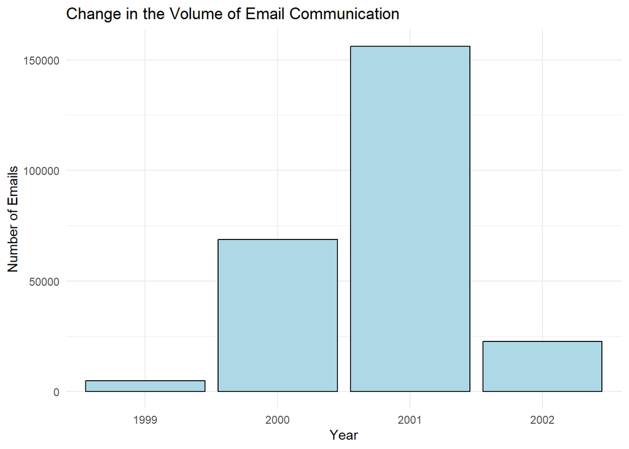

```r
# Create a histogram of email volume over time
emails_per_year <- emails_per_year %>%
  mutate(year = as.factor(year))  # Convert year to a factor to avoid extra years

ggplot(emails_per_year, aes(x = year, y = total_emails)) +
  geom_bar(stat = "identity", color = "black", fill = "lightblue") +
  labs(title = "Change in the Volume of Email Communication",
       x = "Year",
       y = "Number of Emails") +
  theme_minimal()
```

- Find the date with the highest number of sent email

```r
# Group by date, count the number of emails per date, and find the date with the highest count
date_with_max_emails <- message_filtered %>%
  group_by(date) %>%
  summarise(total_emails = n()) %>%
  filter(total_emails == max(total_emails))

# View the result
print(date_with_max_emails)
```

```
## # A tibble: 1 × 2
##   date       total_emails
##   <date>            <int>
## 1 2001-10-25         2207
```

=> Conclusion: The year 2001 recorded the highest number of emails, while October 25 of this year marked the day with the highest email volume, which is nearly half of the total number of emails sent in 1999.

Based on the actual situation, we can infer the trend. From 1999 to 2000, Enron was in its development phase. However, starting in 2001, specifically in mid-2001, the company discovered discrepancies in its financial reports. By November of that year, Enron’s stock price had plummeted from a high of $90 per share in mid-2000 to less than $12. Therefore, it is reasonable to expect the highest volume of emails occurred in October 2001. (Sources: Enron scandal, https://www.britannica.com/event/Enron-scandal/Downfall-and-bankruptcy + https://en.wikipedia.org/wiki/Enron_scandal)

> TOP 10 senders by number of emails for all periods

```r
# Calculate the top 10 senders by number of emails for all periods
top_senders <- message_filtered %>%
  group_by(sender) %>%
  summarise(email_count = n()) %>%
  arrange(desc(email_count)) %>%
  slice_head(n = 10)
# View the result
print(top_senders)
```

```
## # A tibble: 10 × 2
##    sender                        email_count
##    <fct>                               <int>
##  1 jeff.dasovich@enron.com              6273
##  2 j.kaminski@enron.com                 5838
##  3 kay.mann@enron.com                   5100
##  4 sara.shackleton@enron.com            4797
##  5 tana.jones@enron.com                 4437
##  6 chris.germany@enron.com              3686
##  7 no.address@enron.com                 3510
##  8 enron.announcements@enron.com        2838
##  9 matthew.lenhart@enron.com            2784
## 10 debra.perlingiere@enron.com          2549
```

- Connect with the employeelist to extract the full_name of senders

```r
sender_fullname <- inner_join(top_senders, employeelist_long_update, by = c("sender" = "email_id"))

print(sender_fullname)
```

```
## # A tibble: 8 × 9
##   sender   email_count   eid firstname lastname folder status num_email fullname
##   <chr>          <int> <dbl> <chr>     <chr>    <chr>  <chr>  <chr>     <chr>
## 1 jeff.da…        6273    73 Jeff      Dasovich dasov… Emplo… email1    Jeff Da…
## 2 j.kamin…        5838   109 Vince     Kaminski kamin… Manag… email1    Vince K…
## 3 kay.man…        5100    52 Kay       Mann     mann-k Emplo… email1    Kay Mann
## 4 sara.sh…        4797    67 Sara      Shackle… shack… N/A    email1    Sara Sh…
## 5 tana.jo…        4437    48 Tana      Jones    jones… N/A    email1    Tana Jo…
## 6 chris.g…        3686   114 Chris     Germany  germa… Emplo… email1    Chris G…
## 7 matthew…        2784    61 Matthew   Lenhart  lenha… Emplo… email1    Matthew…
## 8 debra.p…        2549    76 Debra     Perling… perli… Emplo… email1    Debra P…
```

> After connecting the data, two email addresses, no.address@enron.com and enron.announcements@enron.com, are recognized as general email accounts within the ENRON company. As a result, these emails cannot display the full name.

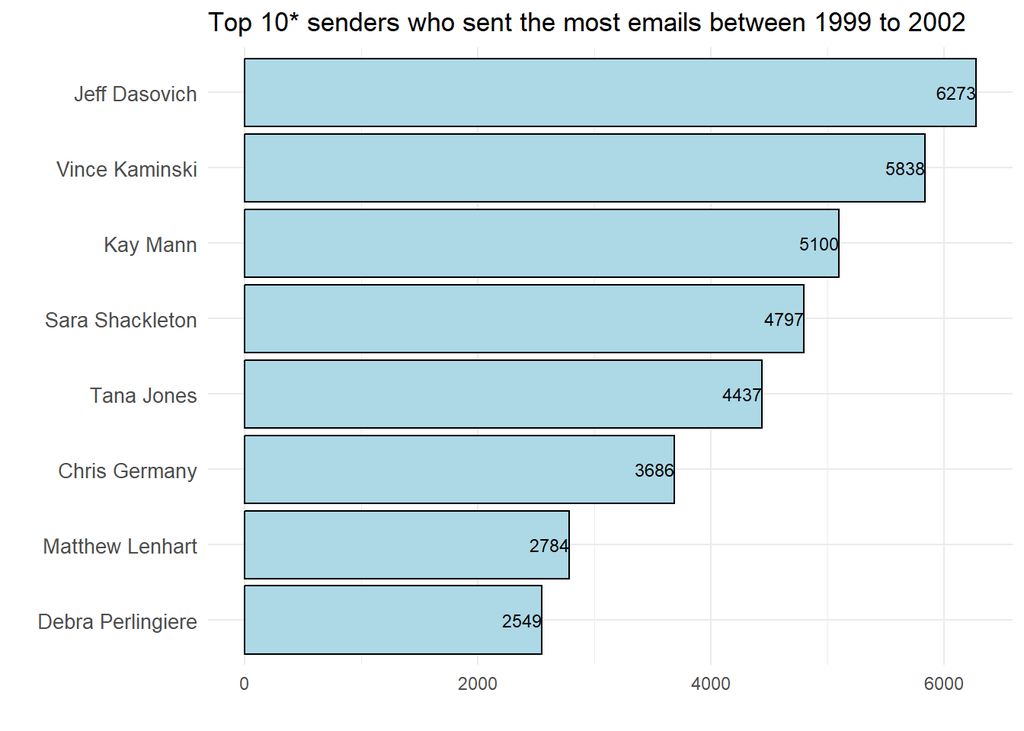

```r
# Horizontal bar chart for top 10 email senders
ggplot(sender_fullname, aes(x = reorder(fullname, email_count), y = email_count)) +
  geom_bar(stat = "identity", fill = "lightblue", color = "black") +
  geom_text(aes(label = email_count), hjust = 1, color = "black", size = 3) +
  labs(
    title = "Top 10* senders who sent the most emails between 1999 to 2002",
    x = " ",
    y = " "
  ) +
  theme_minimal() +
  theme(
    axis.text.y = element_text(size = 10),
    legend.position = "none"
  ) +
  coord_flip()
```

Conclusion: `Jeff Dasovich` is the top senders, with 6273 emails sent, reaching a wide network within the company

- Top 10 senders by number of emails for each year

```r
# Calculate the top 10 senders by number of emails for each year
top_senders_by_year <- message_filtered %>%
  mutate(year = format(date, "%Y")) %>%
  filter(year %in% c("1999", "2000", "2001", "2002")) %>%
  group_by(year, sender) %>%
  summarise(email_count = n(), .groups = "drop") %>%
  arrange(year, desc(email_count)) %>%  #
  group_by(year) %>%
  slice_head(n = 10)

# View the result
print (top_senders_by_year)
```

```
## # A tibble: 40 × 3
## # Groups:   year [4]
##    year  sender                      email_count
##    <chr> <fct>                             <int>
##  1 1999  sara.shackleton@enron.com           770
##  2 1999  mark.e.taylor@enron.com             633
##  3 1999  tana.jones@enron.com                592
##  4 1999  gerald.nemec@enron.com              344
##  5 1999  richard.b.sanders@enron.com         244
##  6 1999  elizabeth.sager@enron.com           139
##  7 1999  e..haedicke@enron.com               121
##  8 1999  chris.germany@enron.com             105
##  9 1999  j.kaminski@enron.com                 75
## 10 1999  larry.f.campbell@enron.com           47
## # ℹ 30 more rows
```

- Connect with the employeelist to extract the full_name of senders

```r
top10_sender_eachyear <- inner_join(top_senders_by_year, employeelist_long_update, by = c("sender" = "email_id"))

print(top10_sender_eachyear)
```

```
## # A tibble: 35 × 10
## # Groups:   year [4]
##    year  sender     email_count   eid firstname lastname folder status num_email
##    <chr> <chr>            <int> <dbl> <chr>     <chr>    <chr>  <chr>  <chr>
##  1 1999  sara.shac…         770    67 Sara      Shackle… shack… N/A    email1
##  2 1999  mark.e.ta…         633     6 Mark      Taylor   taylo… Emplo… email1
##  3 1999  tana.jone…         592    48 Tana      Jones    jones… N/A    email1
##  4 1999  gerald.ne…         344    75 Gerald    Nemec    nemec… N/A    email1
##  5 1999  richard.b…         244    14 Richard   Sanders  sande… Vice … email1
##  6 1999  elizabeth…         139    27 Elizabeth Sager    sager… Emplo… email1
##  7 1999  e..haedic…         121    65 Mark      Haedicke haedi… Manag… email1
##  8 1999  chris.ger…         105   114 Chris     Germany  germa… Emplo… email1
##  9 1999  j.kaminsk…          75   109 Vince     Kaminski kamin… Manag… email1
## 10 1999  larry.f.c…          47    43 Larry     Campbell campb… Emplo… email1
## # ℹ 25 more rows
## # ℹ 1 more variable: fullname <chr>
```

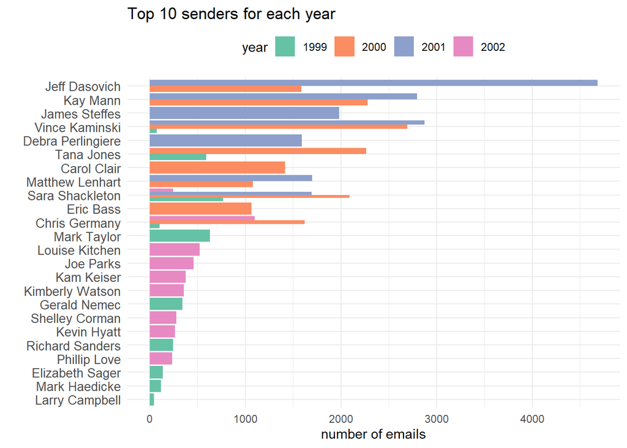

```r
# Create the horizontal grouped bar chart
ggplot(top10_sender_eachyear, aes(x = reorder(fullname, email_count), y = email_count, fill = year)) +
  geom_bar(stat = "identity", position = "dodge") +
  labs(
    title = "Top 10 senders for each year",
    x = " ",
    y = "number of emails"
  ) +
  theme_minimal() +
  theme(
    axis.text.y = element_text(size = 10),
    legend.position = "top"
  ) +
  scale_fill_brewer(palette = "Set2") +
  coord_flip()
```

> show the status of top 10 senders

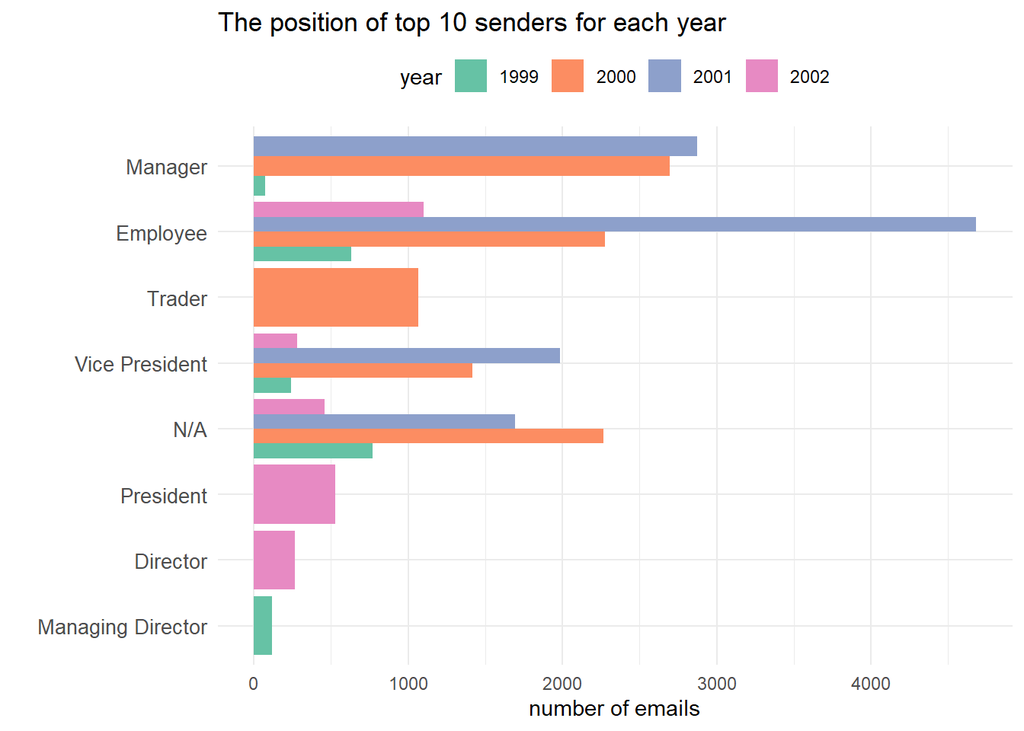

```r
# Create the horizontal grouped bar chart

ggplot(top10_sender_eachyear, aes(x = reorder(status, email_count), y = email_count, fill = year)) +
  geom_bar(stat = "identity", position = "dodge") +
  labs(
    title = "The position of top 10 senders for each year",
    x = " ",
    y = "number of emails"
  ) +
  theme_minimal() +
  theme(
    axis.text.y = element_text(size = 10),
    legend.position = "top"
  ) +
  scale_fill_brewer(palette = "Set2") +
  coord_flip()
```

=> The majority of emails were sent by employees, managers, and vice presidents, with a focus on 2001, the year of Enron’s collapse.

> Table 3: Recipientinfo

```r
head(recipientinfo, 10)
```

```
##    rid mid rtype                            rvalue
## 1   67  52    TO           all.worldwide@enron.com
## 2   68  53    TO            all.downtown@enron.com
## 3   69  54    TO     all.enron-worldwide@enron.com
## 4   70  55    TO           all.worldwide@enron.com
## 5   71  56    TO all_enron_north.america@enron.com
## 6   72  56    TO       ec.communications@enron.com
## 7   73  57    TO                charlotte@wptf.org
## 8   74  58    TO             sap.mailout@enron.com
## 9   75  59    TO           robert.badeer@enron.com
## 10  76  60    TO              tim.belden@enron.com
```

- Count: how many type of email

```r
# Count the type of email

rtype_counts <- table(recipientinfo$rtype)

print(rtype_counts)
```

```
##
##     BCC      CC      TO
##  253713  253735 1556994
```

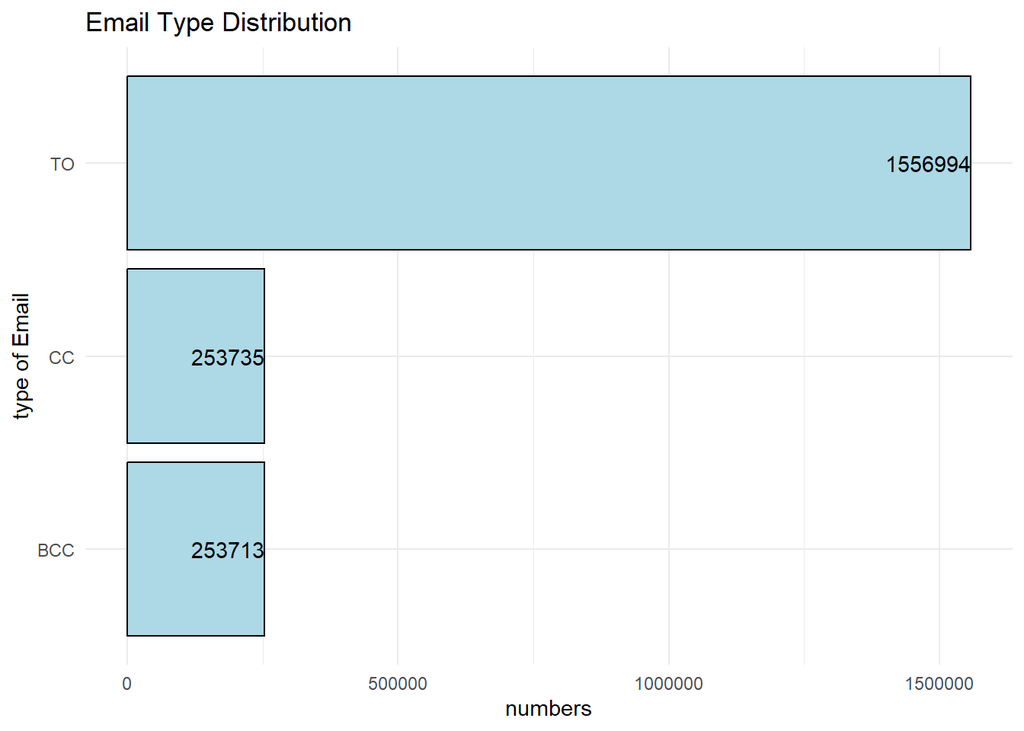

```r
# develop the bar chart

rtype_counts <- as.data.frame(table(recipientinfo$rtype))

# Rename columns for clarity
colnames(rtype_counts) <- c("rtype", "count")

# Create a horizontal bar chart
ggplot(rtype_counts, aes(x = count, y = reorder(rtype, count))) +
  geom_bar(stat = "identity", fill = "lightblue", color = "black") +
  geom_text(aes(label = count), hjust = 1) +

  labs(title = "Email Type Distribution",
       x = "numbers",
       y = "type of Email") +
  theme_minimal()
```

=> Actually, one email can be send to many people, so check the unique message with type TO & count how many mid send to more than one person

```r
# Filter for unique messages with type TO
unique_message_to <- recipientinfo %>%
  filter(rtype == "TO") %>%
  distinct(mid, .keep_all = TRUE)

# Count the number of unique emails with type TO
unique_message_count <- nrow(unique_message_to)

# Print the number of unique emails
print(unique_message_count)
```

```
## [1] 252759
```

```r
# Count how many unique mid were sent to more than one person
messages_to_multiple <- recipientinfo %>%
  distinct(mid, rvalue, .keep_all = TRUE) %>%
  group_by(mid) %>%
  summarise(recipient_count = n()) %>%
  filter(recipient_count > 1)

# Count the number of such messages
number_of_messages <- nrow(messages_to_multiple)

# Print the result
print(number_of_messages)
```

```
## [1] 105896
```

- Top the email was sent during this time

```r
# Find the mid with the highest number of recipients
top_message <- recipientinfo %>%
  filter(rtype == "TO") %>%
  group_by(mid) %>%
  summarise(recipient_count = n()) %>%
  arrange(desc(recipient_count)) %>%
  slice(1)

# Print the top message
print(top_message)
```

```
## # A tibble: 1 × 2
##      mid recipient_count
##    <dbl>           <int>
## 1 270269            1029
```

=> Connect to the referenceinfo table to see the detailed message, but it is unclear why this information cannot be found there. I guess that this message is not in referenceinfo

```r
find_message <- inner_join(top_message, referenceinfo, by = "mid")
print(find_message)
```

```
## # A tibble: 0 × 4
## # ℹ 4 variables: mid <dbl>, recipient_count <int>, rfid <int>, reference <chr>
```

> Table 4: Referenceinfor
- See the content of the email sent during the highest number of email (25/10/2001)

```r
# Filter 'message' for the highest number of emails
filtered_message <- message_filtered %>%
  filter(date == as.Date("2001-10-25"))

# Perform the inner join with 'referenceinfo'
message_content <- inner_join(filtered_message, referenceinfo, by = "mid")

# Print the result
head(message_content, 2)
```

```
##    mid                sender       date
## 1 1318 kevin.hyatt@enron.com 2001-10-25
## 2 1319 kevin.hyatt@enron.com 2001-10-25
##                                      message_id
## 1 <15432627.1075861770354.JavaMail.evans@thyme>
## 2 <15435517.1075861770333.JavaMail.evans@thyme>
##                                                                      subject
## 1 RE: UBS PAINEWEBBER - APPOINTMENT W/ MICHAEL GAPINKSI on 10/26 @ 8:00 a.m.
## 2                                               RE: Sun Devil Weekly Meeting
##   rfid
## 1  176
## 2  177
##                                                                                                                                                                                                                                                                                                          …
## 1 From: Herrera, Rafael J. [mailto:rafael.herrera@ubspainewebber.com]Sent: Thursday, October 25, 2001 10:31 AMTo:  kevin_hyatt@enron.com Subject: UBS PAINEWEBBER - APPOINTMENT W/ MICHAEL GAPINKSI on 10/26 @8:00 a.m. Kevin-This note is to confirm your appointment with Michael Gapinski tomorrow at8…
## 2                                                                                                                                                                                                                                                                                                        …
```

```r
# List of stop words to exclude
custom_stop_words <- c("re", "fw", "for", "and", "to", "enron", "s", "01", "on", "how", "of", "in", "the", "eol", "today", "with")

# Analyze the 'subject' column from the 'content' dataset
subject_words <- message_content %>%
  select(subject) %>%
  unnest_tokens(word, subject) %>%
  filter(!word %in% custom_stop_words) %>%
  count(word, sort = TRUE)

# Display the top 3 most mentioned words
print(head(subject_words, 3))
```

```
##      word  n
## 1      10 43
## 2    2001 38
## 3 meeting 34
```

=> ‘10’, ‘2001’, and ‘meeting’ are the most frequently mentioned words in the subject lines of all emails on 25/10/2001. On this day, Enron was more likely to organize additional meetings